# **Comparative analysis of gene expression profiles between Alzheimer’s-related genes and healthy controls using Neuron.**

## **DESeq2 Framework Using PyDESeq2**

Design: 3 **Control** vs 3 Alzheimer Diseased (**AD**)

### **What is RNA-Seq?**

RNA sequencing (RNA-Seq) is a high-throughput method used to measure gene expression by sequencing cDNA derived from RNA molecules.

The general workflow is:

1. RNA extraction
2. Library preparation
3. Sequencing
4. Read alignment (or pseudo-alignment)
5. Counting reads per gene
6. Statistical modeling of counts
7. Identification of differentially expressed genes

In this notebook, we begin at Step 6 — using a gene count matrix.

```python
!pip install pydeseq2
```

[output not shown]

```python
import pandas as pd
import numpy as np
import matplotlib.pyplot as plt
import seaborn as sns
from pydeseq2.dds import DeseqDataSet
from pydeseq2.ds import DeseqStats
from sklearn.decomposition import PCA
from sklearn.preprocessing import StandardScaler
plt.style.use('seaborn-v0_8')
```

## **Load Count Matrix**

```python
counts = pd.read_csv('/content/counts_Neuron.csv', index_col=0)
counts.head()
```

| Geneid | Control_1 | AD_1 | AD_2 | AD_3 | Control_2 | Control_3 |
| --- | --- | --- | --- | --- | --- | --- |
| ENSG00000279928 | 0 | 0 | 0 | 0 | 0 | 0 |
| ENSG00000228037 | 3 | 1 | 0 | 1 | 2 | 1 |
| ENSG00000142611 | 2 | 4 | 5 | 2 | 4 | 0 |
| ENSG00000284616 | 0 | 0 | 0 | 0 | 0 | 0 |
| ENSG00000157911 | 1 | 1 | 0 | 1 | 0 | 0 |

```python
counts.shape
```

```
(62754, 6)
```

## **Create Metadata (3 Control, 3 AD)**

### **Experimental Design**

In this experiment:

- 3 Biological Replicates (Control)
- 3 Biological Replicates (AD)

Why replicates matter: Biological replicates allow us to estimate biological variability. Without replicates, we cannot estimate dispersion properly.

Statistical power in RNA-seq depends heavily on:

- Number of replicates
- Sequencing depth
- Effect size

```python
# Remove the incorrect re-indexing, as 'Geneid' is already the index from csv load.
# counts = counts.set_index(counts.columns[0])

# Keep only numeric columns
# counts = counts.select_dtypes(include=[np.number])

# Confirm
print("Shape:", counts.shape)
print("Columns:", counts.columns.tolist())

# Create metadata based on column names for robustness
sample_names = counts.columns.tolist()
conditions = []
for name in sample_names:
    if 'Control' in name:
        conditions.append('control')
    elif 'AD' in name:
        conditions.append('AD')
    else:
        conditions.append('unknown') # Fallback for unexpected names

metadata = pd.DataFrame(
    {"condition": conditions},
    index=counts.columns
)

metadata
```

```
Shape: (62754, 6)
Columns: ['Control_1', 'AD_1', 'AD_2', 'AD_3', 'Control_2', 'Control_3']
```

|  | condition |
| --- | --- |
| Control_1 | control |
| AD_1 | AD |
| AD_2 | AD |
| AD_3 | AD |
| Control_2 | control |
| Control_3 | control |

```python
counts.head()
```

| Geneid | Control_1 | AD_1 | AD_2 | AD_3 | Control_2 | Control_3 |
| --- | --- | --- | --- | --- | --- | --- |
| ENSG00000279928 | 0 | 0 | 0 | 0 | 0 | 0 |
| ENSG00000228037 | 3 | 1 | 0 | 1 | 2 | 1 |
| ENSG00000142611 | 2 | 4 | 5 | 2 | 4 | 0 |
| ENSG00000284616 | 0 | 0 | 0 | 0 | 0 | 0 |
| ENSG00000157911 | 1 | 1 | 0 | 1 | 0 | 0 |

### **Sanity Checks: Data Type**

```python
print("Counts DataFrame Info:")
display(counts.info())

print("\nMetadata DataFrame Info:")
display(metadata.info())
```

```
Counts DataFrame Info:
<class 'pandas.core.frame.DataFrame'>
Index: 62754 entries, ENSG00000279928 to ENSG00000275405
Data columns (total 6 columns):
 #   Column     Non-Null Count  Dtype
---  ------     --------------  -----
 0   Control_1  62754 non-null  int64
 1   AD_1       62754 non-null  int64
 2   AD_2       62754 non-null  int64
 3   AD_3       62754 non-null  int64
 4   Control_2  62754 non-null  int64
 5   Control_3  62754 non-null  int64
dtypes: int64(6)
memory usage: 3.4+ MB
```

```
None
```

```
Metadata DataFrame Info:
<class 'pandas.core.frame.DataFrame'>
Index: 6 entries, Control_1 to Control_3
Data columns (total 1 columns):
 #   Column     Non-Null Count  Dtype
---  ------     --------------  -----
 0   condition  6 non-null      object
dtypes: object(1)
memory usage: 268.0+ bytes
```

```
None
```

### **Sanity Checks: Missing Values Summary**

```python
print("Missing values in Counts DataFrame:")
display(counts.isnull().sum().to_frame(name='Missing Values'))

print("\nMissing values in Metadata DataFrame:")
display(metadata.isnull().sum().to_frame(name='Missing Values'))
```

```
Missing values in Counts DataFrame:
```

|  | Missing Values |
| --- | --- |
| Control_1 | 0 |
| AD_1 | 0 |
| AD_2 | 0 |
| AD_3 | 0 |
| Control_2 | 0 |
| Control_3 | 0 |

```
Missing values in Metadata DataFrame:
```

|  | Missing Values |
| --- | --- |
| condition | 0 |

### **Sanity Checks: Duplicate Rows/Columns in Counts**

```python
print("Number of duplicate rows in Counts DataFrame:", counts.duplicated().sum())
print("Number of duplicate columns in Counts DataFrame:", counts.T.duplicated().sum())
```

```
Number of duplicate rows in Counts DataFrame: 36061
Number of duplicate columns in Counts DataFrame: 0
```

#### **Number of duplicate rows in Counts DataFrame: 36,061**

> This means that out of the total 62,754 genes (rows) in the counts DataFrame, 36,061 rows have identical expression values across all samples. In RNA-seq data, this often corresponds to genes that are either not expressed at all (all counts are zero) or genes that have very similar expression patterns across all samples, leading to identical count vectors.

> While these are technically 'duplicates' in terms of their count profiles, they are usually distinct genes identified by their Geneid. It's important to remember that duplicated() checks for identical values across columns, not identical Geneid identifiers. If these are truly separate genes with the same expression pattern, it's not necessarily an error, but it does mean a significant portion of the data might be uninformative for differential expression (e.g., all zeros).

### **Sanity Checks: Descriptive Statistics for Counts**

```python
print("Descriptive statistics for Counts DataFrame:")
display(counts.describe())
```

```
Descriptive statistics for Counts DataFrame:
```

|  | Control_1 | AD_1 | AD_2 | AD_3 | Control_2 | Control_3 |
| --- | --- | --- | --- | --- | --- | --- |
| count | 6.275400e+04 | 6.275400e+04 | 6.275400e+04 | 6.275400e+04 | 62754.000000 | 6.275400e+04 |
| mean | 1.925928e+02 | 2.120884e+02 | 2.329835e+02 | 3.220290e+02 | 66.893632 | 8.140381e+01 |
| std | 3.129095e+04 | 3.711972e+04 | 3.276015e+04 | 5.874077e+04 | 3610.355065 | 1.174209e+04 |
| min | 0.000000e+00 | 0.000000e+00 | 0.000000e+00 | 0.000000e+00 | 0.000000 | 0.000000e+00 |
| 25% | 0.000000e+00 | 0.000000e+00 | 0.000000e+00 | 0.000000e+00 | 0.000000 | 0.000000e+00 |
| 50% | 1.000000e+00 | 0.000000e+00 | 0.000000e+00 | 0.000000e+00 | 0.000000 | 0.000000e+00 |
| 75% | 6.000000e+00 | 6.000000e+00 | 5.000000e+00 | 4.000000e+00 | 8.000000 | 2.000000e+00 |
| max | 7.688675e+06 | 9.274078e+06 | 7.843262e+06 | 1.435220e+07 | 890233.000000 | 2.866690e+06 |

### **The DESeq2 Statistical Model**

DESeq2 models gene counts using a Negative Binomial distribution:

Counts ~ Negative Binomial(mean, dispersion)

Why not a Poisson model?

Poisson assumes: Variance = Mean

RNA-seq data shows: Variance > Mean (Overdispersion)

The Negative Binomial model introduces a dispersion parameter to account for biological variability.

```python
# PyDeseq needs the transpose of our data
counts = counts.T

# Remove duplicate genes
counts = counts.loc[:, ~counts.columns.duplicated()]

# Sanity check
assert counts.shape[0] == metadata.shape[0], "Sample mismatch!"

# Run DESeq2
dds = DeseqDataSet(
    counts=counts,
    metadata=metadata,
    design='~ condition',
    refit_cooks=True
)

dds.deseq2()
```

```
Fitting size factors...
... done in 0.04 seconds.
```

```
Using None as control genes, passed at DeseqDataSet initialization
```

```
Fitting dispersions...
... done in 53.85 seconds.

Fitting dispersion trend curve...
... done in 1.08 seconds.

Fitting MAP dispersions...
... done in 69.06 seconds.

Fitting LFCs...
... done in 59.88 seconds.

Calculating cook's distance...
... done in 0.04 seconds.

Replacing 0 outlier genes.
```

```python
display(counts)
```

| Geneid | ENSG00000279928 | ENSG00000228037 | ENSG00000142611 | ENSG00000284616 | ENSG00000157911 | ENSG00000269896 | ENSG00000228463 | ENSG00000260972 | ENSG00000224340 | ENSG00000226374 | ... | ENSG00000276351 | ENSG00000276345 | ENSG00000273532 | ENSG00000275063 | ENSG00000277856 | ENSG00000271254 | ENSG00000275987 | ENSG00000268674 | ENSG00000277475 | ENSG00000275405 |
| --- | --- | --- | --- | --- | --- | --- | --- | --- | --- | --- | --- | --- | --- | --- | --- | --- | --- | --- | --- | --- | --- |
| Control_1 | 0 | 3 | 2 | 0 | 1 | 4 | 3 | 0 | 0 | 0 | ... | 0 | 0 | 0 | 0 | 0 | 18 | 0 | 0 | 0 | 0 |
| AD_1 | 0 | 1 | 4 | 0 | 1 | 6 | 3 | 0 | 0 | 2 | ... | 0 | 0 | 0 | 0 | 0 | 8 | 0 | 0 | 0 | 0 |
| AD_2 | 0 | 0 | 5 | 0 | 0 | 0 | 5 | 0 | 0 | 0 | ... | 0 | 0 | 0 | 0 | 0 | 6 | 0 | 0 | 0 | 3 |
| AD_3 | 0 | 1 | 2 | 0 | 1 | 3 | 3 | 3 | 0 | 1 | ... | 0 | 0 | 0 | 0 | 0 | 10 | 0 | 0 | 0 | 0 |
| Control_2 | 0 | 2 | 4 | 0 | 0 | 0 | 2 | 0 | 0 | 0 | ... | 0 | 0 | 0 | 0 | 0 | 7 | 0 | 0 | 0 | 0 |
| Control_3 | 0 | 1 | 0 | 0 | 0 | 2 | 1 | 0 | 0 | 0 | ... | 0 | 0 | 0 | 0 | 0 | 2 | 0 | 0 | 0 | 0 |

6 rows × 62754 columns

### **What Happens During dds.deseq2()?**

This performs three major steps:

1. Size Factor Estimation
   - Normalizes for sequencing depth differences
   - Uses median-of-ratios method
2. Dispersion Estimation
   - Estimates biological variability per gene
   - Shrinks dispersions toward a fitted trend
3. Model Fitting
   - Fits a Negative Binomial GLM for each gene

## **Wald Test**

After fitting the model, we test:

H0: log2FoldChange = 0 H1: log2FoldChange ≠ 0

The Wald statistic is:

β / SE(β)

Where:

- β = estimated log2 fold change
- SE = standard error of β

This gives a p-value per gene.

```python
stat_res = DeseqStats(dds, contrast=('condition','AD','control'))
stat_res.run_wald_test()
```

```
Running Wald tests...
... done in 16.96 seconds.
```

```python
stat_res = DeseqStats(dds, contrast=['condition', 'AD', 'control'])
stat_res.summary()  # Does everything in one call
```

```
Running Wald tests...
... done in 17.00 seconds.
```

```
Log2 fold change & Wald test p-value: condition AD vs control
                 baseMean  log2FoldChange     lfcSE      stat    pvalue  \
Geneid
ENSG00000279928  0.000000             NaN       NaN       NaN       NaN
ENSG00000228037  1.233323       -1.420674  1.629162 -0.872027  0.383193
ENSG00000142611  2.736070        1.633998  1.333692  1.225169  0.220512
ENSG00000284616  0.000000             NaN       NaN       NaN       NaN
ENSG00000157911  0.457665        0.879243  2.268191  0.387641  0.698282
...                   ...             ...       ...       ...       ...
ENSG00000271254  8.356093        0.322261  1.117811  0.288297  0.773120
ENSG00000275987  0.000000             NaN       NaN       NaN       NaN
ENSG00000268674  0.000000             NaN       NaN       NaN       NaN
ENSG00000277475  0.000000             NaN       NaN       NaN       NaN
ENSG00000275405  0.821375        3.251768  4.148683  0.783807  0.433153

                     padj
Geneid
ENSG00000279928       NaN
ENSG00000228037  0.986531
ENSG00000142611  0.986531
ENSG00000284616       NaN
ENSG00000157911  0.986531
...                   ...
ENSG00000271254  0.986531
ENSG00000275987       NaN
ENSG00000268674       NaN
ENSG00000277475       NaN
ENSG00000275405  0.986531

[62754 rows x 6 columns]
```

```python
results = stat_res.results_df
results_clean = results.dropna(subset=['padj', 'log2FoldChange', 'baseMean'])
significant_genes = results_clean[results_clean['padj'] < 0.1]
print(f"Number of significant genes (padj < 0.1) in results_clean: {len(significant_genes)}")
display(significant_genes.head())
```

```
Number of significant genes (padj < 0.1) in results_clean: 0
```

|  | baseMean | log2FoldChange | lfcSE | stat | pvalue | padj |
| --- | --- | --- | --- | --- | --- | --- |
| Geneid |  |  |  |  |  |  |

```python
significant_upregulated_genes_fc2 = results_clean[results_clean['log2FoldChange'] > 2]
print(f"Number of significant genes (log2FoldChange > 2) in results_clean: {len(significant_upregulated_genes_fc2)}")
display(significant_upregulated_genes_fc2.head())
```

```
Number of significant genes (log2FoldChange > 2) in results_clean: 6886
```

| Geneid | baseMean | log2FoldChange | lfcSE | stat | pvalue | padj |
| --- | --- | --- | --- | --- | --- | --- |
| ENSG00000260972 | 0.724674 | 3.084399 | 4.099365 | 0.752409 | 0.451805 | 0.986531 |
| ENSG00000226374 | 0.406329 | 2.333642 | 2.809493 | 0.830627 | 0.406184 | 0.986531 |
| ENSG00000232596 | 1.062933 | 3.605108 | 3.179376 | 1.133904 | 0.256835 | 0.986531 |
| ENSG00000171621 | 3.413129 | 2.185974 | 1.601660 | 1.364818 | 0.172310 | 0.986531 |
| ENSG00000284694 | 0.921679 | 3.397412 | 2.417654 | 1.405251 | 0.159947 | 0.986531 |

**Note**

> The above code looks only for genes with positive log2 fold changes greater than 2 (upregulated genes).

```python
significant_abs_log2fc_gt_2 = results_clean[abs(results_clean['log2FoldChange']) > 2]
print(f"Number of significant genes (|log2FoldChange| > 2) in results_clean: {len(significant_abs_log2fc_gt_2)}")
display(significant_abs_log2fc_gt_2.head())
```

```
Number of significant genes (|log2FoldChange| > 2) in results_clean: 8699
```

| Geneid | baseMean | log2FoldChange | lfcSE | stat | pvalue | padj |
| --- | --- | --- | --- | --- | --- | --- |
| ENSG00000260972 | 0.724674 | 3.084399 | 4.099365 | 0.752409 | 0.451805 | 0.986531 |
| ENSG00000226374 | 0.406329 | 2.333642 | 2.809493 | 0.830627 | 0.406184 | 0.986531 |
| ENSG00000232596 | 1.062933 | 3.605108 | 3.179376 | 1.133904 | 0.256835 | 0.986531 |
| ENSG00000171621 | 3.413129 | 2.185974 | 1.601660 | 1.364818 | 0.172310 | 0.986531 |
| ENSG00000284694 | 0.921679 | 3.397412 | 2.417654 | 1.405251 | 0.159947 | 0.986531 |

**Note**

> While the last code looks for genes where the magnitude of the log2 fold change (either positive or negative) is greater than 2 (both upregulated and downregulated genes).

#### **Summary of the Results**

The above results DataFrame is the most important output of the differential expression analysis. It contains the statistical results for every gene tested with the following key summaries.

> **baseMean:** This is the mean of the normalized count values, taken over all samples, for each gene. It's an indicator of the gene's average expression level. Genes with very low baseMean are often less reliable for differential expression analysis.

> **log2FoldChange:** This is the estimated log2 fold change of gene expression between the two conditions compared (AD vs. control). A positive value means the gene is upregulated in AD, while a negative value means it's downregulated. For example, a log2FoldChange of 1 means a 2-fold increase, and -1 means a 2-fold decrease.

> **lfcSE:** This is the standard error of the log2FoldChange estimate. A smaller standard error indicates a more precise estimate of the fold change.

> **stat:** This is the Wald statistic, calculated as log2FoldChange / lfcSE. It's a measure of how far the observed log2FoldChange is from zero, relative to its standard error.

> **pvalue:** This is the nominal p-value from the Wald test, indicating the probability of observing a log2FoldChange as extreme as, or more extreme than, the one observed, assuming the null hypothesis (no differential expression) is true.

> **padj:** This is the adjusted p-value, which is the p-value corrected for multiple testing using the Benjamini-Hochberg method. This is the most crucial metric for determining statistical significance, as it controls the False Discovery Rate (FDR). Typically, genes with padj < 0.05 are considered statistically significant

```python
upregulated_genes = results_clean[results_clean['log2FoldChange'] > 2]
downregulated_genes = results_clean[results_clean['log2FoldChange'] < -2]

print(f"Number of upregulated genes (log2FoldChange > 2): {len(upregulated_genes)}")
print(f"Number of downregulated genes (log2FoldChange < -2): {len(downregulated_genes)}")
```

```
Number of upregulated genes (log2FoldChange > 2): 6886
Number of downregulated genes (log2FoldChange < -2): 1813
```

**Comments**

> This means a larger number of genes are upregulated than downregulated when considering a strong fold change threshold of 2 (equivalent to a 4-fold change).

```python
results_clean = results.dropna(subset=['padj', 'log2FoldChange', 'baseMean'])
```

```python
results_clean.head()
```

| Geneid | baseMean | log2FoldChange | lfcSE | stat | pvalue | padj |
| --- | --- | --- | --- | --- | --- | --- |
| ENSG00000228037 | 1.233323 | -1.420674 | 1.629162 | -0.872027 | 0.383193 | 0.986531 |
| ENSG00000142611 | 2.736070 | 1.633998 | 1.333692 | 1.225169 | 0.220512 | 0.986531 |
| ENSG00000157911 | 0.457665 | 0.879243 | 2.268191 | 0.387641 | 0.698282 | 0.986531 |
| ENSG00000269896 | 2.483293 | 0.093089 | 1.846065 | 0.050425 | 0.959783 | 0.994059 |
| ENSG00000228463 | 3.250169 | 1.375016 | 1.275500 | 1.078022 | 0.281024 | 0.986531 |

### **Multiple Testing Problem**

In RNA-seq, we test thousands of genes simultaneously.

If we use p < 0.05: We expect 5% false positives by chance.

Solution: Benjamini-Hochberg correction

This controls the False Discovery Rate (FDR).

Adjusted p-values are called: padj

## **Why Log2 Fold Change Shrinkage?**

Low-count genes often show exaggerated fold changes.

Shrinkage:

- Pulls extreme fold changes toward zero
- Improves stability
- Makes effect sizes more reliable
- Improves ranking of genes

This is strongly recommended for interpretation.

## **Get Results Table**

**Columns include:**

baseMean

log2FoldChange

lfcSE

stat

pvalue

padj

## **MA Plot**

M = log2 Fold Change  
A = Average Expression

The MA plot shows:

- X-axis: Mean expression
- Y-axis: Log2 Fold Change

It helps visualize:

- Expression-dependent bias
- Stability of fold changes
- Symmetry around zero

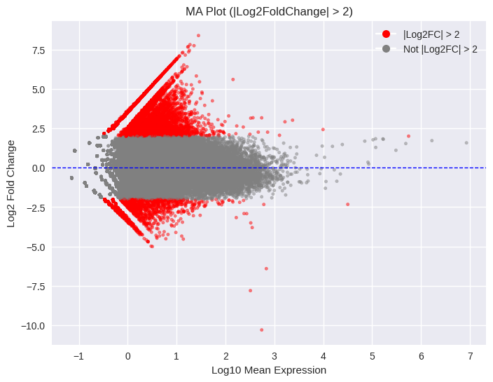

```python
# MA Plot
plt.figure(figsize=(8, 6))

# Filter out baseMean values that are zero before applying log10
plot_data = results[results['baseMean'] > 0]
sig = abs(plot_data['log2FoldChange']) > 2  # Stricter criterion: highlight based on |log2FoldChange| > 2
colors = ['red' if s else 'gray' for s in sig]

plt.scatter(
    np.log10(plot_data['baseMean']),
    plot_data['log2FoldChange'],
    c=colors,
    alpha=0.5,
    s=10
)

plt.axhline(0, color='blue', linestyle='--', linewidth=1)
plt.xlabel('Log10 Mean Expression')
plt.ylabel('Log2 Fold Change')
plt.title('MA Plot (|Log2FoldChange| > 2)') # Update title to reflect new stricter threshold
plt.legend(handles=[
    plt.Line2D([0], [0], marker='o', color='w', markerfacecolor='red', markersize=8, label='|Log2FC| > 2'),
    plt.Line2D([0], [0], marker='o', color='w', markerfacecolor='gray', markersize=8, label='Not |Log2FC| > 2')
])
plt.show()
```

```python
highlighted_genes_ma_plot = results[
    (results['baseMean'] > 0) &
    (abs(results['log2FoldChange']) > 2)
]

print(f"Number of genes highlighted in red on the MA plot: {len(highlighted_genes_ma_plot)}")
display(highlighted_genes_ma_plot.head())
```

```
Number of genes highlighted in red on the MA plot: 8717
```

| Geneid | baseMean | log2FoldChange | lfcSE | stat | pvalue | padj |
| --- | --- | --- | --- | --- | --- | --- |
| ENSG00000260972 | 0.724674 | 3.084399 | 4.099365 | 0.752409 | 0.451805 | 0.986531 |
| ENSG00000226374 | 0.406329 | 2.333642 | 2.809493 | 0.830627 | 0.406184 | 0.986531 |
| ENSG00000232596 | 1.062933 | 3.605108 | 3.179376 | 1.133904 | 0.256835 | 0.986531 |
| ENSG00000171621 | 3.413129 | 2.185974 | 1.601660 | 1.364818 | 0.172310 | 0.986531 |
| ENSG00000284694 | 0.921679 | 3.397412 | 2.417654 | 1.405251 | 0.159947 | 0.986531 |

#### **Interpretation of the MA plot**

> **Red points:** These genes have an absolute log2FoldChange greater than 2 (|Log2FC| > 2), meaning their expression level changed by at least 4-fold between AD and Control conditions. These are considered to have a biologically significant effect size.

> **Gray points:** These genes have an absolute log2FoldChange less than or equal to 2, indicating less pronounced changes in expression.

> **Blue dashed line at Y=0:** This line represents no change in expression (log2FoldChange = 0).

#### **Gene Count Output**

> **Number of genes with |log2FoldChange| > 2:** 8,717. Yes, red points representing genes with |log2FoldChange| > 2 is visible on the MA plot.

> This means that out of all the genes analyzed, 8,717 genes showed a significant change in expression (at least 4-fold up or down) between the AD and Control groups, based solely on the log2FoldChange threshold. These are the genes colored red on the plot.

> This plot helps identify genes with substantial expression changes, regardless of their statistical significance (p-value), which is a different metric.

### **Genes with NaN `padj` values**

```python
nan_padj_genes = results[results['padj'].isna()]
print(f"Number of genes with NaN padj: {len(nan_padj_genes)}")
display(nan_padj_genes.head(10)[['baseMean', 'log2FoldChange', 'pvalue', 'padj']])

print("\nDescriptive statistics for baseMean of NaN padj genes:")
display(nan_padj_genes['baseMean'].describe())
```

```
Number of genes with NaN padj: 18236
```

| Geneid | baseMean | log2FoldChange | pvalue | padj |
| --- | --- | --- | --- | --- |
| ENSG00000279928 | 0.0 | NaN | NaN | NaN |
| ENSG00000284616 | 0.0 | NaN | NaN | NaN |
| ENSG00000224340 | 0.0 | NaN | NaN | NaN |
| ENSG00000231510 | 0.0 | NaN | NaN | NaN |
| ENSG00000284739 | 0.0 | NaN | NaN | NaN |
| ENSG00000272235 | 0.0 | NaN | NaN | NaN |
| ENSG00000286448 | 0.0 | NaN | NaN | NaN |
| ENSG00000241326 | 0.0 | NaN | NaN | NaN |
| ENSG00000142606 | 0.0 | NaN | NaN | NaN |
| ENSG00000227169 | 0.0 | NaN | NaN | NaN |

```
Descriptive statistics for baseMean of NaN padj genes:
```

|  | baseMean |
| --- | --- |
| count | 18236.000000 |
| mean | 2.665477 |
| std | 245.387394 |
| min | 0.000000 |
| 25% | 0.000000 |
| 50% | 0.000000 |
| 75% | 0.000000 |
| max | 31814.840428 |

**dtype:** float64

#### **Interpretation**

> This happens because:

> DESeq2 (and pydeseq2) performs internal filtering to remove genes that have very low or zero counts across all samples.

> For these genes:
> 1. No reliable estimation: The model cannot reliably estimate parameters like log2FoldChange or dispersion for genes with zero or extremely low expression, as there isn't enough data to perform a meaningful statistical test.
> 2. Increased power: Removing these genes helps to increase the statistical power for the remaining genes by reducing the number of multiple comparisons.

```python
# Sort plot_data by absolute log2FoldChange in descending order and display the top 10 genes
top_log2fc_genes = plot_data.sort_values(by='log2FoldChange', key=abs, ascending=False)
display(top_log2fc_genes.head(10)[['baseMean', 'log2FoldChange', 'padj']])
```

| Geneid | baseMean | log2FoldChange | padj |
| --- | --- | --- | --- |
| ENSG00000252594 | 551.878486 | -10.297502 | NaN |
| ENSG00000188388 | 28.089528 | 8.386640 | 0.986531 |
| ENSG00000147138 | 18.827159 | 7.809668 | 0.986531 |
| ENSG00000188306 | 324.206632 | -7.802645 | NaN |
| ENSG00000125815 | 22.724710 | 7.746041 | NaN |
| ENSG00000084110 | 17.331262 | 7.690154 | 0.986531 |
| ENSG00000257137 | 16.960769 | 7.656999 | 0.986531 |
| ENSG00000265453 | 18.344043 | 7.447639 | 0.986531 |
| ENSG00000204978 | 17.656390 | 7.348171 | 0.986531 |
| ENSG00000287440 | 13.415793 | 7.320691 | 0.986531 |

## **Volcano Plot**

The Volcano plot combines:

- Effect size (log2FoldChange)
- Statistical significance (-log10 FDR)

Genes in: Upper left → Downregulated Upper right → Upregulated

Common thresholds:

- padj < 0.05
- |log2FC| > 1

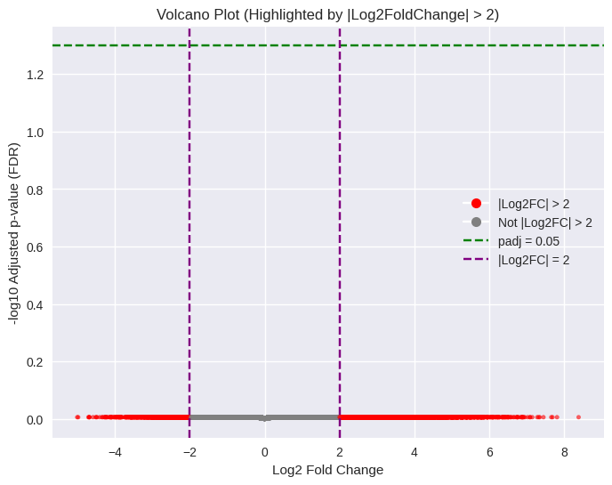

```python
plt.figure(figsize=(8,6))

# Filter out NaNs from relevant columns for plotting
plot_data_volcano = results.dropna(subset=['log2FoldChange', 'padj'])

# Highlight based on |log2FoldChange| > 2, to match the MA plot
sig_color = abs(plot_data_volcano['log2FoldChange']) > 2
colors = ['red' if s else 'gray' for s in sig_color]

plt.scatter(plot_data_volcano['log2FoldChange'], -np.log10(plot_data_volcano['padj']), c=colors, alpha=0.6, s=10)

# Add standard threshold lines for reference
plt.axhline(-np.log10(0.05), color='green', linestyle='--', label='padj < 0.05')
plt.axvline(-2, color='purple', linestyle='--', label='Log2FC = -2') # Updated to -2
plt.axvline(2, color='purple', linestyle='--', label='Log2FC = 2')   # Updated to 2

plt.xlabel('Log2 Fold Change')
plt.ylabel('-log10 Adjusted p-value (FDR)')
plt.title('Volcano Plot (Highlighted by |Log2FoldChange| > 2)') # Updated title

# Create custom legend handles for clarity
legend_handles = [
    plt.Line2D([0], [0], marker='o', color='w', markerfacecolor='red', markersize=8, label='|Log2FC| > 2'), # Updated legend
    plt.Line2D([0], [0], marker='o', color='w', markerfacecolor='gray', markersize=8, label='Not |Log2FC| > 2'), # Updated legend
    plt.Line2D([0], [0], color='green', linestyle='--', label='padj = 0.05'),
    plt.Line2D([0], [0], color='purple', linestyle='--', label='|Log2FC| = 2') # Updated legend
]
plt.legend(handles=legend_handles)

plt.show()
```

#### **Interpretation of points and regions**

> The Volcano Plot is a powerful visualization that helps us understand the relationship between the magnitude of gene expression changes (effect size) and their statistical significance.

> **X-axis (Log2 Fold Change):** This represents the change in gene expression between the AD and control conditions. A positive value means the gene is upregulated in AD, while a negative value means it's downregulated. The further a point is from zero on the x-axis, the greater the magnitude of the change.

> **Y-axis (-log10 Adjusted p-value (FDR)):** This axis shows the statistical significance of the differential expression. Higher values on the y-axis correspond to smaller (more significant) adjusted p-values. A common threshold for significance is padj < 0.05, which would appear as a horizontal line at -log10(0.05) ≈ 1.3.

> **Red points:** These genes are highlighted because their absolute log2FoldChange is greater than 2 (|log2FoldChange| > 2). This means their expression level changed by at least 4-fold (either up or down) between AD and Control conditions. These genes are considered to have a biologically significant effect size.

> **Gray points:** These are genes with an absolute log2FoldChange less than or equal to 2, indicating smaller changes in expression.

> **Green dashed horizontal line:** This line represents the statistical significance threshold, where padj = 0.05. Genes plotted above this line are considered statistically significant.

> **Purple dashed vertical lines:** These lines are at Log2FC = -2 and Log2FC = 2. They mark the boundaries for genes with at least a 4-fold change in expression.

**Interpreting the Regions:**

> **Upper-right region (above green, to the right of purple +2 line):** Genes here are both significantly upregulated and show a large fold change (at least 4-fold increase). These are typically the most interesting genes for further study.

> **Upper-left region (above green, to the left of purple -2 line):** Genes here are both significantly downregulated and show a large fold change (at least 4-fold decrease). These are also highly interesting candidates.

> **Genes between the purple vertical lines and above the green horizontal line:** These genes are statistically significant but have a smaller fold change (less than 4-fold).

> **Genes below the green horizontal line:** These genes are not considered statistically significant, regardless of their fold change.

## **Conclusion**

> **Small Sample Size:** With only 3 biological replicates per condition, the statistical power to detect subtle yet significant gene expression changes is severely limited. DESeq2's statistical model relies on sufficient replicates to accurately estimate biological dispersion (variability), which is crucial for robust p-value calculation.

> **High Intrinsic Variability:** The raw count data displayed high gene-wise variability (large standard deviations and CVs), which is typical for RNA-seq. However, with limited replicates, distinguishing true biological signal from noise becomes difficult.

> **No Clear Strong Signals:** Despite some genes showing large |log2FoldChange| values in the MA plot, these changes did not achieve statistical significance after multiple testing correction, suggesting that these observed fold changes might be due to chance or high variability rather than consistent biological differences.

> In conclusion, while the current analysis didn't identify significant individual genes, the methodology was sound given the data limitations. The path forward involves strengthening the experimental design, particularly by increasing the sample size, to enable a more powerful and conclusive differential expression analysis.

## **Actionable Insights & Recommendations**

> Given these findings, here are actionable insights and recommendations for moving forward:

> **1. Increase Sample Size:** This is the most crucial recommendation. Obtaining more biological replicates for both the AD and control groups would drastically increase the statistical power of the analysis, allowing DESeq2 to more accurately estimate dispersion and detect potentially subtle, but true, differential expression. Aim for at least 6-10 replicates per group if feasible.

> **3. Consider Pathway/Gene Set Enrichment Analysis:** Since individual gene-level significance was not achieved, consider if groups of genes (e.g., genes within a specific pathway or known AD-related gene sets) show subtle but coordinated changes. Tools like GSEA or GO/KEGG enrichment could reveal pathway-level deregulation even if individual genes aren't strongly significant.

> **4. Alternative Differential Expression Methods:** While DESeq2 is highly regarded, exploring other robust differential expression tools like edgeR or limma-voom could provide alternative perspectives, especially if issues with DESeq2's dispersion estimation persist. Some tools may perform better with very small sample sizes or specific data characteristics.

> **5. Validation of High Fold Change Genes:** For genes with a high |log2FoldChange| but not statistical significance, consider validating their expression changes using orthogonal methods (e.g., qRT-PCR) if biological resources allow. This could help determine if these are false positives or true biological signals missed due to limited statistical power.

> **6. Review Experimental Design/Data Quality:** Confirm that sample preparation, sequencing depth, and read alignment were optimal and consistent across all samples. High technical variability can also mask biological signals.

## **Variance Stabilizing Transformation (VST)**

RNA-seq counts have:

- Mean-dependent variance

VST reduces this dependency.

This makes data suitable for:

- PCA
- Clustering
- Heatmaps

Important: VST is used for visualization, NOT for differential testing.

## **Interpreting Results**

A gene is typically considered significantly differentially expressed if:

- padj < 0.05
- |log2FoldChange| > 1

Interpretation guide:

log2FC = 1 → 2-fold increase  
log2FC = -1 → 2-fold decrease  
log2FC = 2 → 4-fold increase

Always consider:

- Biological relevance
- Pathway involvement
- Replicate consistency
- Effect size, not just p-value

```python
!jupyter nbconvert --to html RNA_Seq_PyDESeq2_Neurodegenearative_DDG_N.ipynb
```

```
[NbConvertApp] Converting notebook RNA_Seq_PyDESeq2_Neurodegenearative_DDG_N.ipynb to html
[NbConvertApp] WARNING | Alternative text is missing on 2 image(s).
[NbConvertApp] Writing 595071 bytes to RNA_Seq_PyDESeq2_Neurodegenearative_DDG_N.html
```